# Etude comparative de trois étiqueteurs morpho-syntaxiques * Discours : presse et forum de santé * Etiqueteurs : Spacy, StanfordNLP, TreeTagger Enrichissement de corpus

Xingyu LIU & Xiaoou WANG

07/04/2020

# 1. Introduction

## Enrichissement de corpus - corpus segmenté et annoté

- tokénisation
- lemmatisation
- étiquetage morphosyntaxique
  - parties du discours
  - entités nommées
  - segmentation en chunks codage BILOU
  - arbre des constituants syntaxiques

# 2. Constitution du corpus de la presse

## Métadonnées

- 100 articles
- domaine : culture
- 54621 mots
- documentation détaillée du processus sur xiaoouwang.github.io

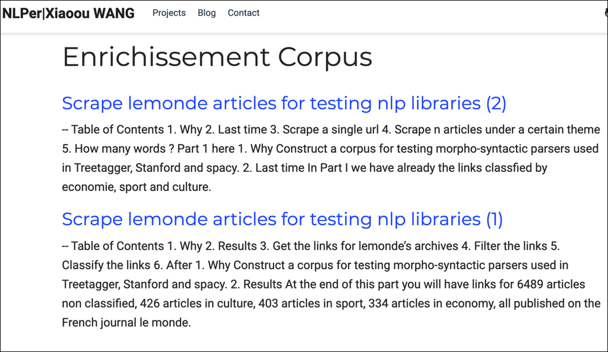

## Source

Les archives de « le monde » :

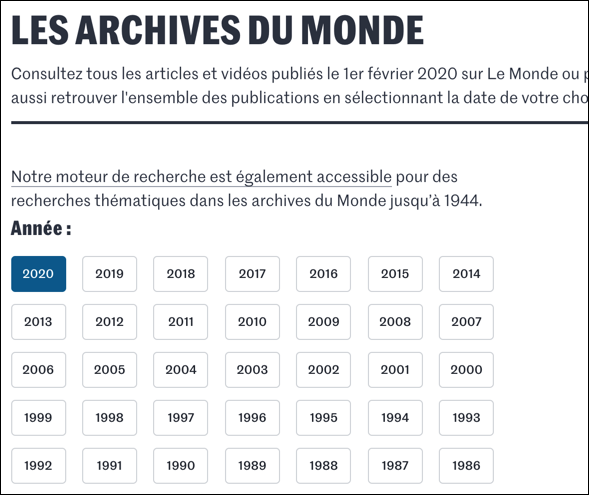

## Générer les dates d’archives

- cette fonction permet de générer les dates sous format jour-mois-année
- + “https://www.lemonde.fr/archives-du-monde/”

```python
def getArchiveLinks(daystart, dayend, monthstart, monthend):
    dates = [str(i).zfill(2)+"-"+str(j).zfill(2) +
             "-2019" for i in range(daystart, dayend) for j in range(monthstart, monthend)]
    archive_links = [
        "https://www.lemonde.fr/archives-du-monde/" + date + "/" for date in dates]
    return archive_links
archive_links = getArchiveLinks(1,29,1,9)
print(archive_links[:5])
```

[output not shown]

## Obtenir les liens des articles

- l’important c’est de filter les articles réservés aux abonnés

[figure not shown]

## Aspirer avec la librairie `beautiful soup`

```python
def getArticlesLinks(archive_links):
    links_non_abonne = []
    for link in archive_links:
        try:
            html = urlopen(link)
        except HTTPError as e:
            print("text url not valid", link)
        soup = BeautifulSoup(html, "html.parser")
        temp = soup.find_all(class_="teaser")
        for item in temp:
            # condition here : if no span sr-only (abonnes)
            if not item.find('span', {'class': 'sr-only'}):
                links_non_abonne.append(item.find('a')['href'])
    return links_non_abonne
```

- Les liens se trouvent dans une balise `teaser`
- Les articles réservés contiennent une class `sr-only`
- liens des 6489 articles disponibles [ici](https://gist.github.com/xiaoouwang/b7fc0c28c72b5b508aaa1dcb34a8b0a6)

## Classer les liens

- le lien contient le thème dans le corps : https://www.lemonde.fr/sport/article/*
- trois thèmes sont définis ici : themes = [‘culture’, ‘sport’, ‘economie’]
- 426 articles en culture, 403 en sport et 334 en économie

```python
def classifyLinks(themeList, linkFile):
    dict_links = defaultdict(list)
    for theme in themeList:
        theme_link = 'https://www.lemonde.fr/'+theme+'.*'
        p = re.compile(theme_link)
        theme_links = p.findall(links)
        [dict_links[theme].append(link) for link in theme_links if 'en-direct' not in link]
    return dict_links

links = readFile('lemonde/lemondeLinks.txt')
themes = ['culture', 'sport', 'economie']

dict_links = classifyLinks(themes, links)

for key, value in dict_links.items():
    print(key, len(value))
# culture 426
# sport 403
# economie 334
```

## Aspirer les articles

- l’article se trouve dans une balise `article`
- le titre dans une balise `h1`
- le corps dans des balises `h2` et `p`
- recursive = False pour ne pas aspirer des balises imbriquées

```python
def getSinglePage(url):
    try:
        html = urlopen(url)
    except HTTPError as e:
        print("text url not valid")
    soup = BeautifulSoup(html, "html.parser")
    with open('html.html','w') as f:
        f.write(soup.prettify())
    # balise h1
    text_title = soup.find('h1')
    # recursive=False
    # balises p et h2
    text_body = soup.article.find_all(["p", "h2"], recursive=False)
    return (text_title, text_body)
```

## Extraire les contenus

3 paramètres :

- numberOfArticles: 100
- dic_links: {‘economie’:links,‘culture’:links,‘sport’:links}
- theme: ‘culture’
- résultat: 100 articles, 54621 mots

```python
def scrapeArticles(numberOfArticles, dict_links, theme):
    for i in range(1, numberOfArticles+1):
        if numberOfArticles <= len(dict_links[theme]):
            singlePage = getSinglePage(dict_links[theme][i])
            with open(('lemonde/'+ theme + str(i) + '.txt'), 'w') as f:
                f.write("## " + singlePage[0].get_text()+"\n"*2)
                for line in singlePage[1]:
                    f.write(line.get_text()+"\n"*2)
        else:
            print("reduce number of articles")
```

## Organisation des fichiers aspirés

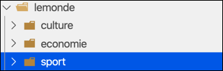

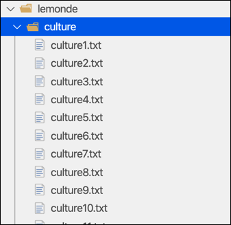

## Exemple d’un texte aspiré classé en `culture`

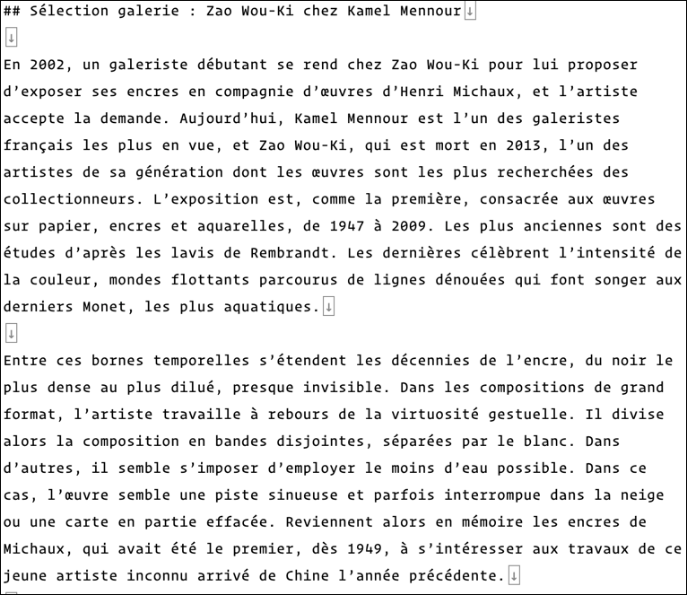

# 3. Constitution du corpus du forum de santé

## Forum santé doctissimo - Mal de dos, sciatique et lumbago

Choix adéquat ?

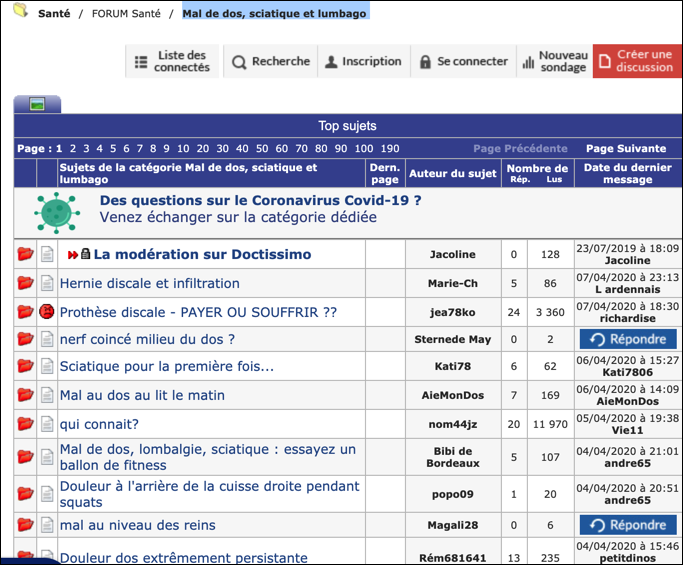

## Métadonnées

Taille du corpus - vers 54621 mots ?

(= la taille du corpus de la presse)

# 4. Questions sur l’évaluation des étiqueteurs

## Critères

- comparer les différences de tokenisation ?
- vitesse
- mesure de précision
- mesure de rappel
- F-mesure
- annotation des entités nommées ?

## Critères II

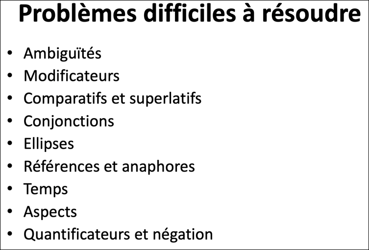